# India Sociolinguistics Face Selection Analyses

#### Muslim face (from audio clip)

|  | V1 | 2.5 % | 97.5 % | toss |
| --- | --- | --- | --- | --- |
| (Intercept) | 0.10 | 0.06 | 0.16 | FALSE |
| child_age_centered | 0.55 | 0.41 | 0.73 | FALSE |
| languageHindi | 9.78 | 5.75 | 17.87 | FALSE |
| languageUrdu | 11.02 | 6.49 | 20.13 | FALSE |
| languageMarathi | 0.37 | 0.13 | 0.92 | FALSE |
| languageMandarin | 0.24 | 0.08 | 0.62 | FALSE |
| child_age_centered:languageHindi | 2.19 | 1.60 | 3.06 | FALSE |
| child_age_centered:languageUrdu | 2.04 | 1.50 | 2.85 | FALSE |
| child_age_centered:languageEnglish (India) | 1.86 | 1.23 | 2.89 | FALSE |

|  | LR Chisq | Df | Pr(>Chisq) |
| --- | --- | --- | --- |
| child_age_centered | 4.1 | 1 | 0.043435954858407378742501947499476955272257328033447265625000000000000000000000000000000000 |
| language | 431.0 | 7 | 0.000000000000000000000000000000000000000000000000000000000000000000000000000000000000000054 |
| child_age_centered:language | 54.6 | 7 | 0.000000001785920717686982432788449237388156420891505149484146386384963989257812500000000000 |

| language | standard | mean |
| --- | --- | --- |
| Gujarati | 3 | 0.346 |
| Gujarati | 5 | 0.052 |
| Gujarati | 7 | 0.064 |
| Hindi | 3 | 0.423 |
| Hindi | 5 | 0.423 |
| Hindi | 7 | 0.606 |
| Urdu | 3 | 0.481 |
| Urdu | 5 | 0.485 |
| Urdu | 7 | 0.585 |
| Marathi | 3 | 0.173 |

[output cut: 15 more lines]

There were significant effects of language ($Wald \chi^2(7)=430.96, p<.001$) and its interaction with child age ($Wald \chi^2(7)=54.6, p<.001$). Children tended to select the muslim face as a speaker of Urdu (52% of trials overall; $OR=11.02 [6.49, 20.13]$), and not to select the muslim face as a speaker of Gujarati (12% of trials; $OR=NA [NA, NA]$), Mandarin (3% of trials; $OR=0.24 [0.08, 0.62]$), and Marathi (6% of trials; $OR=0.37 [0.13, 0.92]$). As children got older, they associated the muslim face with Gujarati even less (35% of trials in 3rd grade to 6% in 7th; $OR=NA [NA, NA]$), and increased their relative selection of it as the speaker of the Hindi (42% of trials in 3rd grade to 61% in 7th; $OR=2.19 [1.60, 3.06]$), Urdu (48% of trials in 3rd grade to 59% in 7th; $OR=2.04 [1.50, 2.85]$), and Indian English ($OR=1.86 [1.23, 2.89]$) audio clips.

#### Dravidian face (from audio clip)

|  | V1 | 2.5 % | 97.5 % | toss |
| --- | --- | --- | --- | --- |
| (Intercept) | 0.34 | 0.25 | 0.45 | FALSE |
| languageHindi | 0.51 | 0.32 | 0.80 | FALSE |
| languageMarathi | 2.15 | 1.47 | 3.18 | FALSE |
| languageEnglish (India) | 0.41 | 0.25 | 0.66 | FALSE |
| languageEnglish (U.S.) | 0.53 | 0.33 | 0.84 | FALSE |
| languageMandarin | 0.10 | 0.04 | 0.21 | FALSE |
| child_age_centered:languageMarathi | 1.28 | 1.01 | 1.62 | FALSE |
| child_age_centered:languageTamil | 1.42 | 1.10 | 1.84 | FALSE |
| child_age_centered:languageMandarin | 0.59 | 0.36 | 0.93 | FALSE |

|  | LR Chisq | Df | Pr(>Chisq) |
| --- | --- | --- | --- |
| child_age_centered | 2.3 | 1 | 0.1308410701098487727289665372 |
| language | 140.9 | 7 | 0.0000000000000000000000000033 |
| child_age_centered:language | 33.9 | 7 | 0.0000180166370368047953280481 |

#### East Asian face (from audio clip)

|  | V1 | 2.5 % | 97.5 % | toss |
| --- | --- | --- | --- | --- |
| (Intercept) | 0.04 | 0.02 | 0.08 | FALSE |
| languageTamil | 4.92 | 2.48 | 10.93 | FALSE |
| languageEnglish (India) | 2.26 | 1.07 | 5.24 | FALSE |
| languageEnglish (U.S.) | 3.49 | 1.70 | 7.89 | FALSE |
| languageMandarin | 57.60 | 29.78 | 126.41 | FALSE |
| child_age_centered:languageMandarin | 1.84 | 1.22 | 2.84 | FALSE |

|  | LR Chisq | Df | Pr(>Chisq) |
| --- | --- | --- | --- |
| child_age_centered | 3.6 | 1 | 0.0588952006571592107109225366912141907960176467895507812500000000000000000000000000000000000000000 |
| language | 466.4 | 7 | 0.0000000000000000000000000000000000000000000000000000000000000000000000000000000000000000000000013 |
| child_age_centered:language | 35.0 | 7 | 0.0000113165827677292776364936094379842757007281761616468429565429687500000000000000000000000000000 |

There was a significant effect of language ($Wald \chi^2(7)=466.43, p<.001$), such that children were likely to select the asian face as the speaker of Mandarin ($OR=57.60 [29.78, 126.41]$), Tamil ($OR=4.92 [2.48, 10.93]$), U.S. English ($OR=3.49 [1.70, 7.89]$), and Indian English ($OR=2.26 [1.07, 5.24]$), and unlikely to select the asian face as the speaker of Gujarati ($OR=0.04 [0.02, 0.08]$). We also saw a significant interaction between language and child age ($Wald \chi^2(7)=34.97, p<.001$), such that as children got older, they increasingly selected the east asian face for Mandarin ($OR=1.84 [1.22, 2.84]$).

#### White face (from audio clip)

|  | V1 | 2.5 % | 97.5 % | toss |
| --- | --- | --- | --- | --- |
| (Intercept) | 0.03 | 0.01 | 0.07 | FALSE |
| languageTamil | 5.75 | 2.69 | 14.62 | FALSE |
| languageEnglish (India) | 72.23 | 34.93 | 180.50 | FALSE |
| languageEnglish (U.S.) | 62.06 | 29.94 | 155.30 | FALSE |
| languageMandarin | 4.08 | 1.86 | 10.53 | FALSE |
| child_age_centered:languageEnglish (India) | 1.80 | 1.15 | 2.94 | FALSE |
| child_age_centered:languageEnglish (U.S.) | 2.22 | 1.41 | 3.63 | FALSE |

|  | LR Chisq | Df | Pr(>Chisq) |
| --- | --- | --- | --- |
| child_age_centered | 0.84 | 1 | 0.35990311374090228069277941358450334519147872924804687500000000000000000000000000000000000000000000000000000000000000000000000000000000000000000000000000 |
| language | 722.14 | 7 | 0.00000000000000000000000000000000000000000000000000000000000000000000000000000000000000000000000000000000000000000000000000000000000000000000000000000012 |
| child_age_centered:language | 62.97 | 7 | 0.00000000003834898172997128583204287328004315153068271015968093706760555505752563476562500000000000000000000000000000000000000000000000000000000000000000 |

### LANGUAGE NAME

```
##
## FALSE  TRUE
##  1664    37
```

```
## [1] 13
```

```
##
##                  hindu                                         asian
##                    411                      0                    279
##        asian dravidian  asian dravidian hindu  asian dravidian white
##                      0                      1                      0
##            asian hindu     asian hindu muslim           asian muslim
##                      1                      0                      0
##     asian muslim white            asian white              dravidian
##                      1                      9                    323
##        dravidian hindu dravidian hindu muslim  dravidian hindu white
##                      6                      4                      0
##       dravidian muslim        dravidian white dravidian white muslim
##                      0                      1                      0
##           hindu muslim            hindu white                    idk
##                     11                      2                     30
##                 muslim           muslim white                  white
##                    355                      1                    266
```

```
## [1] 14
```

```
##
##        Gujarati         English English (India)  English (U.S.)           Hindi
##               1               0               0               0               1
##        Mandarin         Marathi           Tamil            Urdu
##               0               1               1               1
```

#### Hindu face (from language name)

|  | LR Chisq | Df | Pr(>Chisq) |
| --- | --- | --- | --- |
| child_age_centered | 4.8 | 1 | 0.0277355514060459440450756574136903509497642517089843750000000000000000000000000000000000000000000 |
| language | 463.5 | 6 | 0.0000000000000000000000000000000000000000000000000000000000000000000000000000000000000000000000006 |
| child_age_centered:language | 29.7 | 6 | 0.0000453104227265426859230616762896914906377787701785564422607421875000000000000000000000000000000 |

We saw significant effects of language ($Wald \chi^2(6)=463.52, p<.001$), child age ($Wald \chi^2(1)=4.84, p<.05$), and their interaction ($Wald \chi^2(6)=29.68, p<.001$). Children robustly selected the hindu face as a speaker of Gujarati (58% of trials; $OR=1.40 [1.09, 1.82]$), and did so significantly less for Mandarin (2% of trials; $OR=0.01 [0.00, 0.03]$), English (2% of trials; $OR=0.01 [0.00, 0.03]$), Urdu (7% of trials; $OR=0.05 [0.02, 0.08]$), Tamil (25% of trials; $OR=0.24 [0.16, 0.35]$), Hindi (35% of trials; $OR=0.39 [0.27, 0.56]$), and Marathi (49% of trials; $OR=0.68 [0.47, 0.98]$). With age, children became less likely to select the hindu face as the speaker of Urdu (from 15% to 2%; $OR=0.56 [0.38, 0.79]$), Chinese (from 2% to 1%; $OR=0.68 [0.37, 1.20]$), and Tamil (from 31% to 22%; $OR=0.78 [0.61, 0.99]$).

#### Muslim face (from language name)

|  | LR Chisq | Df | Pr(>Chisq) |
| --- | --- | --- | --- |
| child_age_centered | 4 | 1 | 0.045297781652260053764091907169131445698440074920654296875000000000000000000000000000000000000000000000000000000000000000000000000000000000000000000000000 |
| language | 718 | 6 | 0.000000000000000000000000000000000000000000000000000000000000000000000000000000000000000000000000000000000000000000000000000000000000000000000000000000091 |
| child_age_centered:language | 42 | 6 | 0.000000180408523488475431508935766661272381838898581918329000473022460937500000000000000000000000000000000000000000000000000000000000000000000000000000000 |

We saw significant effects of language ($Wald \chi^2(6)=717.73, p<.001$), child age ($Wald \chi^2(1)=4.01, p<.05$), and their interaction ($Wald \chi^2(6)=42.04, p<.001$): with age, children became increasingly likely to select the face as the speaker of Urdu (from 58% of trials in 3rd grade to 93% of trials in 7th; $OR=27.19 [16.50, 46.41]$).

#### Dravidian face (from language name)

|  | LR Chisq | Df | Pr(>Chisq) |
| --- | --- | --- | --- |
| child_age_centered | 0.57 | 1 | 0.4503528735967045060206714879313949495553970336914062500000000000000000000 |
| language | 348.24 | 6 | 0.0000000000000000000000000000000000000000000000000000000000000000000000037 |
| child_age_centered:language | 40.15 | 6 | 0.0000004264114342780207559322738688351028812917320465203374624252319335938 |

- This reflects accurate model of language–phenotype association

#### East Asian face (from language name)

|  | LR Chisq | Df | Pr(>Chisq) |
| --- | --- | --- | --- |
| child_age_centered | 1.7 | 1 | 0.1979045168830437240181652214232599362730979919433593750000000000000000000000000000000000000000000000000000000000000000000000000000000000000000000000000000000 |
| language | 736.6 | 6 | 0.0000000000000000000000000000000000000000000000000000000000000000000000000000000000000000000000000000000000000000000000000000000000000000000000000000000000075 |
| child_age_centered:language | 37.5 | 6 | 0.0000013996801657010087687626640959304147315833688480779528617858886718750000000000000000000000000000000000000000000000000000000000000000000000000000000000000 |

#### White face (from language name)

|  | LR Chisq | Df | Pr(>Chisq) |
| --- | --- | --- | --- |
| child_age_centered | 4.8 | 1 | 0.027712833981050462306416903857098077423870563507080078125000000000000000000000000000000000000000000000000000000000000000000000000000000000000000000000000000000 |
| language | 746.5 | 6 | 0.000000000000000000000000000000000000000000000000000000000000000000000000000000000000000000000000000000000000000000000000000000000000000000000000000000000000056 |
| child_age_centered:language | 32.9 | 6 | 0.000011023060998035518362968797345669003107104799710214138031005859375000000000000000000000000000000000000000000000000000000000000000000000000000000000000000000 |

We saw significant effects of language ($Wald \chi^2(6)=746.48, p<.001$), child age ($Wald \chi^2(1)=4.85, p<.05$), and their interaction ($Wald \chi^2(6)=32.89, p<.001$), such that children showed a preference for the white face when asked about English (83% of all trials; $OR=256.65 [105.03, 869.15]$), Chinese (8% of all trials; $OR=3.71 [1.42, 12.89]$), and Tamil (9% of all trials; $OR=3.82 [1.45, 13.32]$), and a dispreference when asked about Gujarati (3% of all trials; $OR=0.02 [0.01, 0.05]$). With age, children became even more likely to select the white face in response to English (from 73% in 3rd grade to 92% in 7th grade; $OR=2.20 [1.30, 4.08]$) and less likely to select the white face in response to Gujarati (6% down to 1%; $OR=0.62 [0.35, 1.00]$).

# Mixed Effects Multinomial Regression

## AUDIO

```
##
## Iteration 1 - deviance = 4323 - criterion = 0.86
## Iteration 2 - deviance = 4242 - criterion = 0.07
## Iteration 3 - deviance = 4217 - criterion = 0.0079
## Iteration 4 - deviance = 4210 - criterion = 0.00029
## Iteration 5 - deviance = 4210 - criterion = 0.00000015
## Iteration 6 - deviance = 4210 - criterion = 0.00000000000018
```

```
##
## Call:
## mblogit(formula = face ~ language * age, data = fa_for_plots,
##     random = ~1 | id)
##
## Equation for asian vs hindu:
##                             Estimate Std. Error z value             Pr(>|z|)
## (Intercept)                  -2.5032     0.3400   -7.36     0.00000000000018
## languageHindi                 0.8095     0.4854    1.67                0.095
## languageUrdu                  1.5739     0.4801    3.28                0.001
## languageMarathi               0.5033     0.4799    1.05                0.294
## languageTamil                 2.3639     0.4051    5.83     0.00000000538688
## languageEnglish (India)       2.9707     0.5360    5.54     0.00000002984738
## languageEnglish (U.S.)        4.4028     0.6713    6.56     0.00000000005421
## languageMandarin              5.5534     0.5525   10.05 < 0.0000000000000002
## age                          -0.4594     0.2081   -2.21                0.027
## languageHindi:age             0.0846     0.2877    0.29                0.769
## languageUrdu:age              0.5227     0.2882    1.81                0.070
## languageMarathi:age          -0.1027     0.2895   -0.35                0.723
## languageTamil:age             0.0890     0.2502    0.36                0.722
## languageEnglish (India):age   0.3245     0.3236    1.00                0.316
## languageEnglish (U.S.):age    0.3107     0.4044    0.77                0.442
## languageMandarin:age          1.3060     0.3094    4.22     0.00002428297271
##
## (Intercept)                 ***
## languageHindi               .
## languageUrdu                **
## languageMarathi
## languageTamil               ***
## languageEnglish (India)     ***
## languageEnglish (U.S.)      ***
## languageMandarin            ***
## age                         *
## languageHindi:age
## languageUrdu:age            .
## languageMarathi:age
## languageTamil:age
## languageEnglish (India):age
## languageEnglish (U.S.):age
## languageMandarin:age        ***
```

[output cut: 92 more lines]

```
## Signif. codes:  0 '***' 0.001 '**' 0.01 '*' 0.05 '.' 0.1 ' ' 1
##
## (Co-)Variances:
## Grouping level: id
##             Estimate                                                          Std.Err.
## asian~1      0.000002035053                                                   0.000000000000000000751
## dravidian~1  0.000000003138  0.000002037584                                   0.000000000000000000532 0.000000000000000000754
## muslim~1    -0.000000000758  0.000000003638  0.000002038253                   0.000000000000000000532 0.000000000000000000533 0.000000000000000000754
## white~1     -0.000000000249 -0.000000001487  0.000000004534  0.000002040035   0.000000000000000000533 0.000000000000000000534 0.000000000000000000534 0.000000000000000000756
##
## Approximate residual deviance: 4210
## Number of Fisher scoring iterations:  6
## Number of observations
##   Groups by id: 126
##   Individual observations:  1849  (1 observation deleted due to missingness)
```

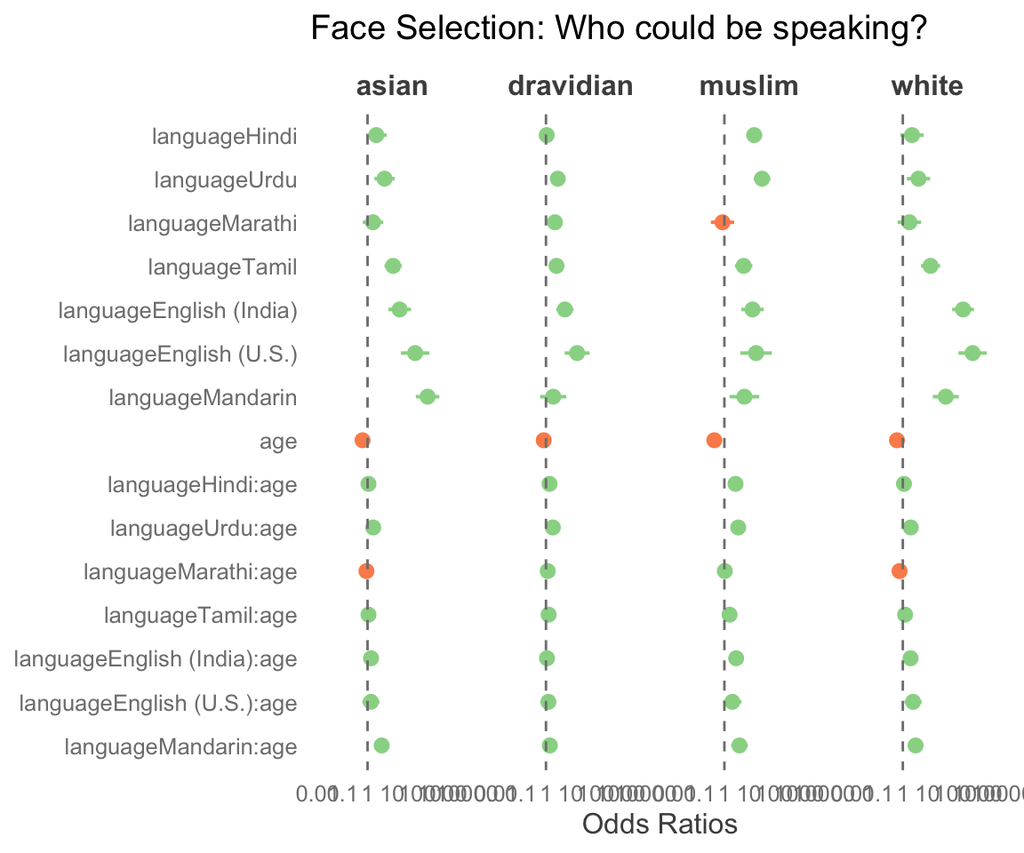

|  | face: asian |  |  | face: dravidian |  |  | face: muslim |  |  | face: white |  |  |
| --- | --- | --- | --- | --- | --- | --- | --- | --- | --- | --- | --- | --- |
| Predictors | Odds Ratios | CI | p | Odds Ratios | CI | p | Odds Ratios | CI | p | Odds Ratios | CI | p |
| (Intercept) | 0.08 | 0.04 – 0.16 | **<0.001** | 0.49 | 0.36 – 0.67 | **<0.001** | 0.11 | 0.06 – 0.22 | **<0.001** | 0.06 | 0.03 – 0.14 | **<0.001** |
| languageHindi | 2.25 | 0.87 – 5.82 | 0.095 | 1.07 | 0.63 – 1.81 | 0.808 | 15.77 | 7.64 – 32.58 | **<0.001** | 2.35 | 0.79 – 6.93 | 0.123 |
| languageUrdu | 4.83 | 1.88 – 12.37 | **0.001** | 2.99 | 1.72 – 5.19 | **<0.001** | 32.50 | 15.09 – 70.03 | **<0.001** | 4.27 | 1.45 – 12.53 | **0.008** |
| languageMarathi | 1.65 | 0.65 – 4.24 | 0.294 | 2.29 | 1.49 – 3.51 | **<0.001** | 0.84 | 0.29 – 2.46 | 0.750 | 1.84 | 0.62 – 5.47 | 0.272 |
| languageTamil | 10.63 | 4.81 – 23.53 | **<0.001** | 2.65 | 1.61 – 4.37 | **<0.001** | 5.95 | 2.66 – 13.33 | **<0.001** | 13.05 | 5.38 – 31.66 | **<0.001** |
| languageEnglish (India) | 19.51 | 6.82 – 55.78 | **<0.001** | 5.76 | 2.59 – 12.81 | **<0.001** | 13.45 | 4.75 – 38.09 | **<0.001** | 263.36 | 96.19 – 721.07 | **<0.001** |
| languageEnglish (U.S.) | 81.68 | 21.91 – 304.52 | **<0.001** | 17.85 | 5.64 – 56.47 | **<0.001** | 18.77 | 4.37 – 80.57 | **<0.001** | 638.61 | 171.57 – 2377.01 | **<0.001** |
| languageMandarin | 258.11 | 87.39 – 762.34 | **<0.001** | 1.96 | 0.58 – 6.56 | 0.277 | 6.36 | 1.62 – 25.05 | **0.008** | 53.19 | 15.96 – 177.26 | **<0.001** |
| age | 0.63 | 0.42 – 0.95 | **0.027** | 0.81 | 0.66 – 0.99 | **0.039** | 0.39 | 0.28 – 0.56 | **<0.001** | 0.58 | 0.37 – 0.92 | **0.020** |
| languageHindi:age | 1.09 | 0.62 – 1.91 | 0.769 | 1.39 | 0.99 – 1.93 | 0.055 | 2.80 | 1.86 – 4.21 | **<0.001** | 1.11 | 0.59 – 2.08 | 0.738 |
| languageUrdu:age | 1.69 | 0.96 – 2.97 | 0.070 | 1.89 | 1.34 – 2.65 | **<0.001** | 3.59 | 2.34 – 5.53 | **<0.001** | 2.09 | 1.09 – 3.99 | **0.026** |
| languageMarathi:age | 0.90 | 0.51 – 1.59 | 0.723 | 1.17 | 0.89 – 1.54 | 0.256 | 1.04 | 0.58 – 1.85 | 0.903 | 0.74 | 0.40 – 1.37 | 0.338 |
| languageTamil:age | 1.09 | 0.67 – 1.79 | 0.722 | 1.28 | 0.93 – 1.75 | 0.132 | 1.62 | 1.02 – 2.57 | **0.042** | 1.24 | 0.72 – 2.11 | 0.438 |
| languageEnglish (India):age | 1.38 | 0.73 – 2.61 | 0.316 | 1.10 | 0.68 – 1.79 | 0.705 | 2.97 | 1.61 – 5.47 | **<0.001** | 2.05 | 1.12 – 3.76 | **0.020** |
| languageEnglish (U.S.):age | 1.36 | 0.62 – 3.01 | 0.442 | 1.25 | 0.62 – 2.52 | 0.529 | 2.08 | 0.89 – 4.85 | 0.089 | 2.58 | 1.17 – 5.70 | **0.019** |
| languageMandarin:age | 3.69 | 2.01 – 6.77 | **<0.001** | 1.43 | 0.75 – 2.70 | 0.274 | 4.04 | 1.88 – 8.66 | **<0.001** | 3.26 | 1.66 – 6.40 | **0.001** |
| N <sub>id</sub> | 126 |  |  |  |  |  |  |  |  |  |  |  |
| Observations | 1849 |  |  |  |  |  |  |  |  |  |  |  |

```
##
## Iteration 1 - deviance = 4084 - criterion = 0.28
## Iteration 2 - deviance = 4036 - criterion = 0.012
## Iteration 3 - deviance = 4034 - criterion = 0.00061
## Iteration 4 - deviance = 4033 - criterion = 0.000081
## Iteration 5 - deviance = 4033 - criterion = 0.000026
## Iteration 6 - deviance = 4033 - criterion = 0.0000097
## Iteration 7 - deviance = 4033 - criterion = 0.0000036
## Iteration 8 - deviance = 4033 - criterion = 0.0000013
## Iteration 9 - deviance = 4033 - criterion = 0.00000048
## Iteration 10 - deviance = 4033 - criterion = 0.00000018
## Iteration 11 - deviance = 4033 - criterion = 0.000000065
## Iteration 12 - deviance = 4033 - criterion = 0.000000024
## Iteration 13 - deviance = 4033 - criterion = 0.0000000088
```

```
##
## Call:
## mblogit(formula = face ~ language * id_correct + age, data = fai)
##
## Equation for asian vs hindu:
##                                    Estimate Std. Error z value Pr(>|z|)
## (Intercept)                         -1.2687     0.5833   -2.18  0.02962 *
## languageHindi                       -0.3308     0.9744   -0.34  0.73421
## languageUrdu                         0.5193     0.6674    0.78  0.43648
## languageMarathi                     -0.1583     0.7400   -0.21  0.83061
## languageTamil                        1.1704     0.6391    1.83  0.06706 .
## languageEnglish (India)              1.4413     0.8878    1.62  0.10448
## languageEnglish (U.S.)              15.3760   599.8816    0.03  0.97955
## languageMandarin                     2.8556     0.6979    4.09 0.000043 ***
## id_correct                          -1.5993     0.7188   -2.23  0.02608 *
## age                                 -0.1475     0.0609   -2.42  0.01548 *
## languageHindi:id_correct             1.5803     1.1161    1.42  0.15679
## languageUrdu:id_correct            -11.3713   456.2557   -0.02  0.98012
## languageMarathi:id_correct           0.5934     0.9699    0.61  0.54068
## languageTamil:id_correct             1.3299     0.8540    1.56  0.11940
## languageEnglish (India):id_correct   1.8343     1.1148    1.65  0.09989 .
## languageEnglish (U.S.):id_correct  -10.1641   599.8822   -0.02  0.98648
## languageMandarin:id_correct          3.2206     0.9327    3.45  0.00055 ***
##
## Equation for dravidian vs hindu:
##                                      Estimate Std. Error z value Pr(>|z|)
## (Intercept)                          0.080175   0.402980    0.20    0.842
## languageHindi                       -0.667914   0.687192   -0.97    0.331
## languageUrdu                         0.302779   0.468914    0.65    0.518
## languageMarathi                      0.492439   0.481165    1.02    0.306
## languageTamil                        0.069322   0.472974    0.15    0.883
## languageEnglish (India)              0.931449   0.708958    1.31    0.189
## languageEnglish (U.S.)              13.406459 599.881641    0.02    0.982
## languageMandarin                    -0.080142   0.641451   -0.12    0.901
## id_correct                          -0.955690   0.442288   -2.16    0.031 *
## age                                  0.000137   0.047980    0.00    0.998
## languageHindi:id_correct             0.869665   0.749689    1.16    0.246
## languageUrdu:id_correct              0.572781   0.869577    0.66    0.510
## languageMarathi:id_correct           0.258950   0.546243    0.47    0.635
## languageTamil:id_correct             1.064021   0.601304    1.77    0.077 .
```

[output cut: 35 more lines]

```
## age                                 -0.0161     0.0572   -0.28     0.778
## languageHindi:id_correct             1.2783     1.4116    0.91     0.365
## languageUrdu:id_correct              1.6757     1.2937    1.30     0.195
## languageMarathi:id_correct          -0.0601     1.0235   -0.06     0.953
## languageTamil:id_correct             0.6602     0.9817    0.67     0.501
## languageEnglish (India):id_correct   1.4273     1.0890    1.31     0.190
## languageEnglish (U.S.):id_correct   -9.5408   599.8822   -0.02     0.987
## languageMandarin:id_correct          1.8498     1.1151    1.66     0.097 .
## ---
## Signif. codes:  0 '***' 0.001 '**' 0.01 '*' 0.05 '.' 0.1 ' ' 1
##
## Approximate residual Deviance: 4030
## Number of Fisher scoring iterations:  13
## Number of observations:  1741
##   (128 observations deleted due to missingness)
```

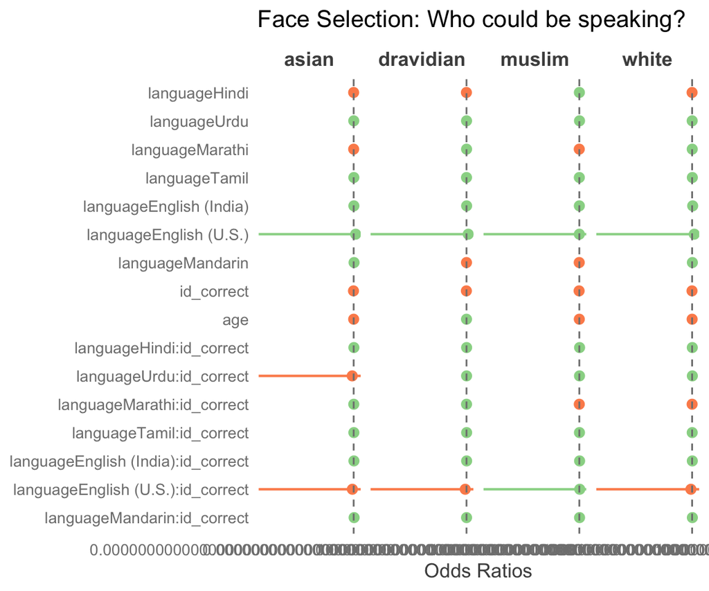

|  | face: asian |  |  | face: dravidian |  |  | face: muslim |  |  | face: white |  |  |
| --- | --- | --- | --- | --- | --- | --- | --- | --- | --- | --- | --- | --- |
| Predictors | Odds Ratios | CI | p | Odds Ratios | CI | p | Odds Ratios | CI | p | Odds Ratios | CI | p |
| (Intercept) | 0.28 | 0.09 – 0.88 | **0.030** | 1.08 | 0.49 – 2.39 | 0.842 | 0.74 | 0.32 – 1.73 | 0.485 | 0.16 | 0.04 – 0.74 | **0.018** |
| languageHindi | 0.72 | 0.11 – 4.85 | 0.734 | 0.51 | 0.13 – 1.97 | 0.331 | 1.70 | 0.51 – 5.68 | 0.392 | 0.67 | 0.05 – 8.64 | 0.761 |
| languageUrdu | 1.68 | 0.45 – 6.22 | 0.436 | 1.35 | 0.54 – 3.39 | 0.518 | 4.71 | 1.83 – 12.11 | **0.001** | 1.43 | 0.26 – 7.93 | 0.683 |
| languageMarathi | 0.85 | 0.20 – 3.64 | 0.831 | 1.64 | 0.64 – 4.20 | 0.306 | 0.62 | 0.20 – 1.88 | 0.397 | 2.19 | 0.40 – 12.02 | 0.366 |
| languageTamil | 3.22 | 0.92 – 11.28 | 0.067 | 1.07 | 0.42 – 2.71 | 0.883 | 1.06 | 0.39 – 2.88 | 0.914 | 5.13 | 1.05 – 25.19 | **0.044** |
| languageEnglish (India) | 4.23 | 0.74 – 24.08 | 0.104 | 2.54 | 0.63 – 10.19 | 0.189 | 1.31 | 0.26 – 6.64 | 0.744 | 68.37 | 11.13 – 419.98 | **<0.001** |
| languageEnglish (U.S.) | 4761207.24 | 0.00 – Inf | 0.980 | 664279.79 | 0.00 – Inf | 0.982 | 1.29 | 0.00 – Inf | 1.000 | 15303889.60 | 0.00 – Inf | 0.978 |
| languageMandarin | 17.39 | 4.43 – 68.27 | **<0.001** | 0.92 | 0.26 – 3.24 | 0.901 | 0.48 | 0.10 – 2.34 | 0.367 | 6.83 | 1.16 – 40.34 | **0.034** |
| id_correct | 0.20 | 0.05 – 0.83 | **0.026** | 0.38 | 0.16 – 0.92 | **0.031** | 0.19 | 0.07 – 0.53 | **0.001** | 0.40 | 0.07 – 2.15 | 0.283 |
| age | 0.86 | 0.77 – 0.97 | **0.015** | 1.00 | 0.91 – 1.10 | 0.998 | 0.90 | 0.81 – 0.99 | **0.037** | 0.98 | 0.88 – 1.10 | 0.778 |
| languageHindi:id_correct | 4.86 | 0.54 – 43.28 | 0.157 | 2.39 | 0.55 – 10.37 | 0.246 | 7.76 | 1.98 – 30.49 | **0.003** | 3.59 | 0.23 – 57.11 | 0.365 |
| languageUrdu:id_correct | 0.00 | 0.00 – Inf | 0.980 | 1.77 | 0.32 – 9.75 | 0.510 | 4.24 | 0.87 – 20.52 | 0.073 | 5.34 | 0.42 – 67.45 | 0.195 |
| languageMarathi:id_correct | 1.81 | 0.27 – 12.11 | 0.541 | 1.30 | 0.44 – 3.78 | 0.635 | 0.79 | 0.16 – 3.91 | 0.776 | 0.94 | 0.13 – 7.00 | 0.953 |
| languageTamil:id_correct | 3.78 | 0.71 – 20.16 | 0.119 | 2.90 | 0.89 – 9.42 | 0.077 | 3.10 | 0.75 – 12.83 | 0.118 | 1.94 | 0.28 – 13.25 | 0.501 |
| languageEnglish (India):id_correct | 6.26 | 0.70 – 55.66 | 0.100 | 2.68 | 0.49 – 14.79 | 0.258 | 9.03 | 1.24 – 66.00 | **0.030** | 4.17 | 0.49 – 35.22 | 0.190 |
| languageEnglish (U.S.):id_correct | 0.00 | 0.00 – Inf | 0.986 | 0.00 | 0.00 – Inf | 0.987 | 27.29 | 0.00 – Inf | 0.997 | 0.00 | 0.00 – Inf | 0.987 |
| languageMandarin:id_correct | 25.04 | 4.03 – 155.81 | **0.001** | 1.56 | 0.23 – 10.81 | 0.652 | 6.16 | 0.60 – 63.64 | 0.127 | 6.36 | 0.71 – 56.57 | 0.097 |
| Observations | 1741 |  |  |  |  |  |  |  |  |  |  |  |
| Nagelkerke’s R<sup>2</sup> | 0.619 |  |  |  |  |  |  |  |  |  |  |  |

```
##
## Iteration 1 - deviance = 3910 - criterion = 0.25
## Iteration 2 - deviance = 3841 - criterion = 0.018
## Iteration 3 - deviance = 3834 - criterion = 0.0017
## Iteration 4 - deviance = 3834 - criterion = 0.00016
## Iteration 5 - deviance = 3834 - criterion = 0.000027
## Iteration 6 - deviance = 3834 - criterion = 0.0000095
## Iteration 7 - deviance = 3834 - criterion = 0.0000035
## Iteration 8 - deviance = 3833 - criterion = 0.0000013
## Iteration 9 - deviance = 3833 - criterion = 0.00000047
## Iteration 10 - deviance = 3833 - criterion = 0.00000017
## Iteration 11 - deviance = 3833 - criterion = 0.000000064
## Iteration 12 - deviance = 3833 - criterion = 0.000000024
## Iteration 13 - deviance = 3833 - criterion = 0.0000000087
```

```
##
## Call:
## mblogit(formula = face ~ language * id_correct * child_age_centered,
##     data = fai[fai$face != "idk" & fai$num_faces == 1, ])
##
## Equation for asian vs hindu:
##                                                       Estimate Std. Error
## (Intercept)                                            -2.0684     1.0514
## languageHindi                                           0.0617     1.5815
## languageUrdu                                            1.3046     1.1068
## languageMarathi                                         0.7552     1.1783
## languageTamil                                           2.0759     1.0905
## languageEnglish (India)                                 2.2473     1.2628
## languageEnglish (U.S.)                                 14.9170   653.5689
## languageMandarin                                        4.4425     1.2398
## id_correct                                             -0.7466     1.1328
## child_age_centered                                     -0.9940     0.5525
## languageHindi:id_correct                                0.9368     1.6849
## languageUrdu:id_correct                                -9.9189   493.6155
## languageMarathi:id_correct                             -0.3110     1.3455
## languageTamil:id_correct                                0.3959     1.2287
## languageEnglish (India):id_correct                      0.8975     1.4405
## languageEnglish (U.S.):id_correct                      -9.8363   653.5695
## languageMandarin:id_correct                             1.9350     1.4723
## languageHindi:child_age_centered                        0.5563     0.7668
## languageUrdu:child_age_centered                         0.9912     0.5892
## languageMarathi:child_age_centered                      0.9771     0.6377
## languageTamil:child_age_centered                        0.4743     0.5771
## languageEnglish (India):child_age_centered              0.8937     0.7103
## languageEnglish (U.S.):child_age_centered               0.1489   319.4281
## languageMandarin:child_age_centered                     1.6658     0.6372
## id_correct:child_age_centered                           0.7132     0.6148
## languageHindi:id_correct:child_age_centered            -0.6634     0.8469
## languageUrdu:id_correct:child_age_centered              0.5324   261.4263
## languageMarathi:id_correct:child_age_centered          -1.2935     0.7596
## languageTamil:id_correct:child_age_centered            -0.1205     0.7010
## languageEnglish (India):id_correct:child_age_centered  -0.7679     0.8226
## languageEnglish (U.S.):id_correct:child_age_centered   -0.3440   319.4286
## languageMandarin:id_correct:child_age_centered         -0.4174     0.7894
##                                                       z value Pr(>|z|)
```

[output cut: 228 more lines]

```
## id_correct:child_age_centered                            1.05    0.295
## languageHindi:id_correct:child_age_centered             -1.32    0.186
## languageUrdu:id_correct:child_age_centered               0.44    0.659
## languageMarathi:id_correct:child_age_centered           -0.81    0.416
## languageTamil:id_correct:child_age_centered             -1.10    0.273
## languageEnglish (India):id_correct:child_age_centered   -0.91    0.361
## languageEnglish (U.S.):id_correct:child_age_centered     0.00    0.996
## languageMandarin:id_correct:child_age_centered          -0.93    0.351
## ---
## Signif. codes:  0 '***' 0.001 '**' 0.01 '*' 0.05 '.' 0.1 ' ' 1
##
## Approximate residual Deviance: 3830
## Number of Fisher scoring iterations:  13
## Number of observations:  1741
##   (128 observations deleted due to missingness)
```

## LABEL

```
##
## Iteration 1 - deviance = 3072 - criterion = 0.81
## Iteration 2 - deviance = 2982 - criterion = 0.071
## Iteration 3 - deviance = 2961 - criterion = 0.019
## Iteration 4 - deviance = 2960 - criterion = 0.0058
## Iteration 5 - deviance = 2960 - criterion = 0.0014
## Iteration 6 - deviance = 2960 - criterion = 0.000068
## Iteration 7 - deviance = 2960 - criterion = 0.0000001
## Iteration 8 - deviance = 2960 - criterion = 0.00000000000021
```

```
##
## Call:
## mblogit(formula = face ~ language * age, data = fl_for_plots,
##     random = ~1 | id)
##
## Equation for asian vs hindu:
##                      Estimate Std. Error z value             Pr(>|z|)
## (Intercept)            -2.989      0.432   -6.92      0.0000000000044 ***
## languageHindi           0.701      0.584    1.20               0.2303
## languageUrdu            2.892      0.604    4.79      0.0000016769136 ***
## languageMarathi         0.355      0.566    0.63               0.5311
## languageTamil           1.585      0.536    2.96               0.0031 **
## languageEnglish         4.647      0.771    6.02      0.0000000016991 ***
## languageMandarin        7.191      0.775    9.28 < 0.0000000000000002 ***
## age                    -0.509      0.239   -2.13               0.0331 *
## languageHindi:age       0.256      0.335    0.76               0.4453
## languageUrdu:age        0.472      0.335    1.41               0.1589
## languageMarathi:age     0.349      0.331    1.06               0.2907
## languageTamil:age       0.166      0.300    0.55               0.5802
## languageEnglish:age     0.461      0.456    1.01               0.3119
## languageMandarin:age    1.041      0.424    2.45               0.0142 *
##
## Equation for dravidian vs hindu:
##                      Estimate Std. Error z value          Pr(>|z|)
## (Intercept)           -1.0273     0.1668   -6.16 0.000000000741112 ***
## languageHindi         -0.2566     0.3059   -0.84           0.40157
## languageUrdu           1.0856     0.4298    2.53           0.01154 *
## languageMarathi        0.7772     0.2216    3.51           0.00045 ***
## languageTamil          1.7681     0.2316    7.63 0.000000000000023 ***
## languageEnglish        1.5434     0.7574    2.04           0.04159 *
## languageMandarin       2.1229     0.7527    2.82           0.00480 **
## age                   -0.0882     0.1034   -0.85           0.39334
## languageHindi:age     -0.1771     0.1857   -0.95           0.34027
## languageUrdu:age       0.2173     0.2497    0.87           0.38433
## languageMarathi:age   -0.2569     0.1383   -1.86           0.06312 .
## languageTamil:age      0.3678     0.1446    2.54           0.01097 *
## languageEnglish:age    0.1102     0.4623    0.24           0.81159
## languageMandarin:age   0.1669     0.4133    0.40           0.68633
##
## Equation for muslim vs hindu:
```

[output cut: 33 more lines]

```
## Signif. codes:  0 '***' 0.001 '**' 0.01 '*' 0.05 '.' 0.1 ' ' 1
##
## (Co-)Variances:
## Grouping level: id
##             Estimate                                                      Std.Err.
## asian~1      0.00001026717                                                0.0000000000000000964
## dravidian~1 -0.00000002889  0.00001027054                                 0.0000000000000000682 0.0000000000000000965
## muslim~1    -0.00000000150 -0.00000001153  0.00001032284                  0.0000000000000000687 0.0000000000000000688 0.0000000000000000980
## white~1     -0.00000000747  0.00000000559 -0.00000002244  0.00001033150   0.0000000000000000688 0.0000000000000000689 0.0000000000000000694 0.0000000000000000982
##
## Approximate residual deviance: 2960
## Number of Fisher scoring iterations:  8
## Number of observations
##   Groups by id: 126
##   Individual observations:  1633  (1 observation deleted due to missingness)
```

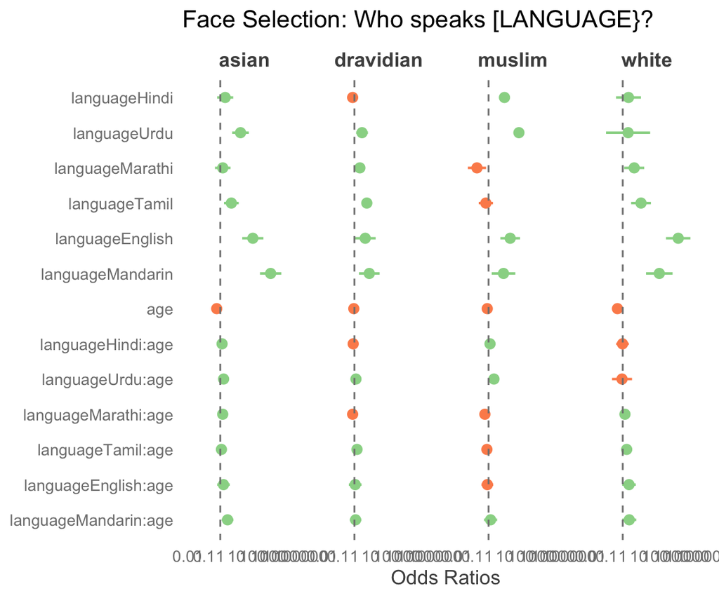

|  | face: asian |  |  | face: dravidian |  |  | face: muslim |  |  | face: white |  |  |
| --- | --- | --- | --- | --- | --- | --- | --- | --- | --- | --- | --- | --- |
| Predictors | Odds Ratios | CI | p | Odds Ratios | CI | p | Odds Ratios | CI | p | Odds Ratios | CI | p |
| (Intercept) | 0.05 | 0.02 – 0.12 | **<0.001** | 0.36 | 0.26 – 0.50 | **<0.001** | 0.16 | 0.10 – 0.26 | **<0.001** | 0.02 | 0.01 – 0.09 | **<0.001** |
| languageHindi | 2.02 | 0.64 – 6.34 | 0.230 | 0.77 | 0.42 – 1.41 | 0.402 | 9.63 | 5.62 – 16.49 | **<0.001** | 2.27 | 0.39 – 13.40 | 0.364 |
| languageUrdu | 18.03 | 5.52 – 58.92 | **<0.001** | 2.96 | 1.28 – 6.88 | **0.012** | 75.84 | 36.14 – 159.12 | **<0.001** | 2.15 | 0.09 – 50.01 | 0.634 |
| languageMarathi | 1.43 | 0.47 – 4.33 | 0.531 | 2.18 | 1.41 – 3.36 | **<0.001** | 0.19 | 0.05 – 0.69 | **0.012** | 5.13 | 1.23 – 21.42 | **0.025** |
| languageTamil | 4.88 | 1.71 – 13.94 | **0.003** | 5.86 | 3.72 – 9.23 | **<0.001** | 0.68 | 0.25 – 1.86 | 0.450 | 13.57 | 3.31 – 55.57 | **<0.001** |
| languageEnglish | 104.32 | 22.99 – 473.33 | **<0.001** | 4.68 | 1.06 – 20.66 | **0.042** | 21.83 | 5.36 – 88.83 | **<0.001** | 2752.85 | 481.83 – 15727.75 | **<0.001** |
| languageMandarin | 1328.01 | 290.63 – 6068.19 | **<0.001** | 8.36 | 1.91 – 36.54 | **0.005** | 8.40 | 1.55 – 45.43 | **0.013** | 184.67 | 27.77 – 1228.21 | **<0.001** |
| age | 0.60 | 0.38 – 0.96 | **0.033** | 0.92 | 0.75 – 1.12 | 0.393 | 0.83 | 0.63 – 1.09 | 0.175 | 0.47 | 0.24 – 0.91 | **0.025** |
| languageHindi:age | 1.29 | 0.67 – 2.49 | 0.445 | 0.84 | 0.58 – 1.21 | 0.340 | 1.23 | 0.88 – 1.71 | 0.226 | 0.97 | 0.40 – 2.37 | 0.942 |
| languageUrdu:age | 1.60 | 0.83 – 3.09 | 0.159 | 1.24 | 0.76 – 2.03 | 0.384 | 2.15 | 1.39 – 3.34 | **0.001** | 0.90 | 0.22 – 3.75 | 0.887 |
| languageMarathi:age | 1.42 | 0.74 – 2.71 | 0.291 | 0.77 | 0.59 – 1.01 | 0.063 | 0.59 | 0.29 – 1.20 | 0.143 | 1.37 | 0.65 – 2.89 | 0.406 |
| languageTamil:age | 1.18 | 0.66 – 2.12 | 0.580 | 1.44 | 1.09 – 1.92 | **0.011** | 0.79 | 0.45 – 1.38 | 0.404 | 1.75 | 0.84 – 3.64 | 0.134 |
| languageEnglish:age | 1.59 | 0.65 – 3.88 | 0.312 | 1.12 | 0.45 – 2.76 | 0.812 | 0.84 | 0.36 – 1.94 | 0.682 | 2.44 | 0.93 – 6.41 | 0.069 |
| languageMandarin:age | 2.83 | 1.23 – 6.50 | **0.014** | 1.18 | 0.53 – 2.66 | 0.686 | 1.33 | 0.52 – 3.38 | 0.553 | 2.53 | 0.93 – 6.89 | 0.069 |
| N <sub>id</sub> | 126 |  |  |  |  |  |  |  |  |  |  |  |
| Observations | 1633 |  |  |  |  |  |  |  |  |  |  |  |

```
##
## Iteration 1 - deviance = 2561 - criterion = 0.13
## Iteration 2 - deviance = 2488 - criterion = 0.029
## Iteration 3 - deviance = 2481 - criterion = 0.0029
## Iteration 4 - deviance = 2479 - criterion = 0.0005
## Iteration 5 - deviance = 2479 - criterion = 0.00017
## Iteration 6 - deviance = 2479 - criterion = 0.000061
## Iteration 7 - deviance = 2479 - criterion = 0.000022
## Iteration 8 - deviance = 2479 - criterion = 0.0000082
## Iteration 9 - deviance = 2479 - criterion = 0.000003
## Iteration 10 - deviance = 2479 - criterion = 0.0000011
## Iteration 11 - deviance = 2479 - criterion = 0.00000041
## Iteration 12 - deviance = 2479 - criterion = 0.00000015
## Iteration 13 - deviance = 2479 - criterion = 0.000000056
## Iteration 14 - deviance = 2479 - criterion = 0.00000002
## Iteration 15 - deviance = 2479 - criterion = 0.0000000075
```

```
##
## Call:
## mblogit(formula = face ~ language * id_correct + age, data = fli)
##
## Equation for asian vs hindu:
##                              Estimate Std. Error z value    Pr(>|z|)
## (Intercept)                   -1.7273     0.5148   -3.36     0.00079 ***
## languageHindi                -14.9525  1051.5966   -0.01     0.98866
## languageUrdu                   1.6226     0.6313    2.57     0.01017 *
## languageMarathi               -0.0556     0.6728   -0.08     0.93410
## languageTamil                  0.2818     0.6473    0.44     0.66338
## languageMandarin               4.9898     0.8856    5.63 0.000000018 ***
## id_correct                    -1.5943     0.7221   -2.21     0.02726 *
## age                           -0.2056     0.0815   -2.52     0.01164 *
## languageHindi:id_correct      16.1904  1051.5968    0.02     0.98772
## languageUrdu:id_correct      -14.1654  1416.0601   -0.01     0.99202
## languageMarathi:id_correct    -0.2434     1.1062   -0.22     0.82585
## languageTamil:id_correct       2.2003     0.9283    2.37     0.01778 *
## languageMandarin:id_correct    3.3877     1.4279    2.37     0.01767 *
##
## Equation for dravidian vs hindu:
##                             Estimate Std. Error z value Pr(>|z|)
## (Intercept)                  -0.9150     0.4043   -2.26   0.0236 *
## languageHindi                -0.3000     0.6979   -0.43   0.6673
## languageUrdu                  0.9165     0.5449    1.68   0.0926 .
## languageMarathi               1.1675     0.4673    2.50   0.0125 *
## languageTamil                 1.7988     0.4555    3.95 0.000078 ***
## languageMandarin              2.5247     0.8740    2.89   0.0039 **
## id_correct                   -0.2642     0.4510   -0.59   0.5580
## age                          -0.0528     0.0519   -1.02   0.3097
## languageHindi:id_correct      0.3803     0.7749    0.49   0.6236
## languageUrdu:id_correct      -0.8909     1.2971   -0.69   0.4922
## languageMarathi:id_correct   -0.6147     0.5405   -1.14   0.2554
## languageTamil:id_correct      0.2516     0.5715    0.44   0.6597
## languageMandarin:id_correct -13.8767   536.6302   -0.03   0.9794
##
## Equation for muslim vs hindu:
##                             Estimate Std. Error z value     Pr(>|z|)
## (Intercept)                  -2.2846     0.7433   -3.07       0.0021 **
## languageHindi                 2.1444     0.8472    2.53       0.0114 *
```

[output cut: 19 more lines]

```
## languageMandarin               4.0607     1.1045    3.68    0.00024 ***
## id_correct                    -0.3431     0.9097   -0.38    0.70607
## age                           -0.4795     0.0929   -5.16 0.00000025 ***
## languageHindi:id_correct       1.1085     1.4492    0.76    0.44436
## languageUrdu:id_correct      -14.3241  1348.8109   -0.01    0.99153
## languageMarathi:id_correct    -0.3805     1.0794   -0.35    0.72449
## languageTamil:id_correct      -0.8336     1.1453   -0.73    0.46673
## languageMandarin:id_correct    1.4959     1.6173    0.92    0.35499
## ---
## Signif. codes:  0 '***' 0.001 '**' 0.01 '*' 0.05 '.' 0.1 ' ' 1
##
## Approximate residual Deviance: 2480
## Number of Fisher scoring iterations:  15
## Number of observations:  1317
##   (96 observations deleted due to missingness)
```

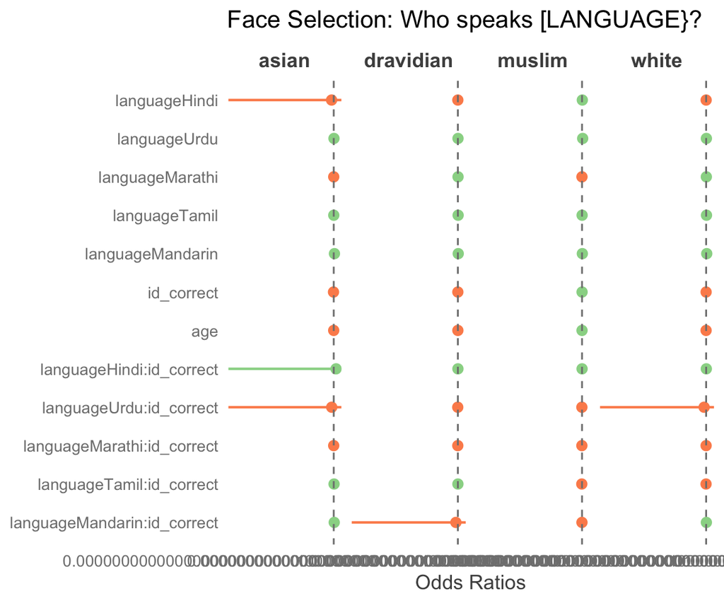

|  | face: asian |  |  | face: dravidian |  |  | face: muslim |  |  | face: white |  |  |
| --- | --- | --- | --- | --- | --- | --- | --- | --- | --- | --- | --- | --- |
| Predictors | Odds Ratios | CI | p | Odds Ratios | CI | p | Odds Ratios | CI | p | Odds Ratios | CI | p |
| (Intercept) | 0.18 | 0.06 – 0.49 | **0.001** | 0.40 | 0.18 – 0.88 | **0.024** | 0.10 | 0.02 – 0.44 | **0.002** | 0.04 | 0.01 – 0.20 | **<0.001** |
| languageHindi | 0.00 | 0.00 – Inf | 0.989 | 0.74 | 0.19 – 2.91 | 0.667 | 8.54 | 1.62 – 44.92 | **0.011** | 0.92 | 0.07 – 11.38 | 0.947 |
| languageUrdu | 5.07 | 1.47 – 17.46 | **0.010** | 2.50 | 0.86 – 7.28 | 0.093 | 101.15 | 21.43 – 477.33 | **<0.001** | 4.74 | 0.75 – 29.97 | 0.098 |
| languageMarathi | 0.95 | 0.25 – 3.54 | 0.934 | 3.21 | 1.29 – 8.03 | **0.012** | 0.67 | 0.09 – 5.19 | 0.706 | 3.57 | 0.68 – 18.81 | 0.134 |
| languageTamil | 1.33 | 0.37 – 4.71 | 0.663 | 6.04 | 2.47 – 14.75 | **<0.001** | 1.90 | 0.36 – 10.16 | 0.451 | 10.25 | 2.09 – 50.22 | **0.004** |
| languageMandarin | 146.91 | 25.90 – 833.34 | **<0.001** | 12.49 | 2.25 – 69.24 | **0.004** | 9.72 | 0.84 – 111.91 | 0.068 | 58.02 | 6.66 – 505.46 | **<0.001** |
| id_correct | 0.20 | 0.05 – 0.84 | **0.027** | 0.77 | 0.32 – 1.86 | 0.558 | 1.46 | 0.31 – 6.87 | 0.633 | 0.71 | 0.12 – 4.22 | 0.706 |
| age | 0.81 | 0.69 – 0.96 | **0.012** | 0.95 | 0.86 – 1.05 | 0.310 | 1.06 | 0.94 – 1.19 | 0.346 | 0.62 | 0.52 – 0.74 | **<0.001** |
| languageHindi:id_correct | 10749750.87 | 0.00 – Inf | 0.988 | 1.46 | 0.32 – 6.68 | 0.624 | 1.46 | 0.25 – 8.60 | 0.673 | 3.03 | 0.18 – 51.88 | 0.444 |
| languageUrdu:id_correct | 0.00 | 0.00 – Inf | 0.992 | 0.41 | 0.03 – 5.21 | 0.492 | 0.37 | 0.05 – 2.94 | 0.350 | 0.00 | 0.00 – Inf | 0.992 |
| languageMarathi:id_correct | 0.78 | 0.09 – 6.85 | 0.826 | 0.54 | 0.19 – 1.56 | 0.255 | 0.36 | 0.03 – 3.90 | 0.397 | 0.68 | 0.08 – 5.67 | 0.724 |
| languageTamil:id_correct | 9.03 | 1.46 – 55.68 | **0.018** | 1.29 | 0.42 – 3.94 | 0.660 | 0.20 | 0.01 – 2.82 | 0.230 | 0.43 | 0.05 – 4.10 | 0.467 |
| languageMandarin:id_correct | 29.60 | 1.80 – 486.08 | **0.018** | 0.00 | 0.00 – Inf | 0.979 | 0.66 | 0.02 – 27.47 | 0.827 | 4.46 | 0.19 – 106.26 | 0.355 |
| Observations | 1317 |  |  |  |  |  |  |  |  |  |  |  |
| Nagelkerke’s R<sup>2</sup> | 0.768 |  |  |  |  |  |  |  |  |  |  |  |

```
##
## Iteration 1 - deviance = 2484 - criterion = 0.1
## Iteration 2 - deviance = 2399 - criterion = 0.035
## Iteration 3 - deviance = 2384 - criterion = 0.0064
## Iteration 4 - deviance = 2380 - criterion = 0.0015
## Iteration 5 - deviance = 2379 - criterion = 0.00035
## Iteration 6 - deviance = 2379 - criterion = 0.000078
## Iteration 7 - deviance = 2379 - criterion = 0.000023
## Iteration 8 - deviance = 2379 - criterion = 0.0000083
## Iteration 9 - deviance = 2379 - criterion = 0.0000031
## Iteration 10 - deviance = 2379 - criterion = 0.0000011
## Iteration 11 - deviance = 2379 - criterion = 0.00000042
## Iteration 12 - deviance = 2379 - criterion = 0.00000015
## Iteration 13 - deviance = 2379 - criterion = 0.000000056
## Iteration 14 - deviance = 2379 - criterion = 0.000000021
## Iteration 15 - deviance = 2379 - criterion = 0.0000000076
```

```
##
## Call:
## mblogit(formula = face ~ language * id_correct * age, data = fli)
##
## Equation for asian vs hindu:
##                                  Estimate Std. Error z value Pr(>|z|)
## (Intercept)                       -1.6746     0.7600   -2.20    0.028 *
## languageHindi                    -14.8907  1135.9133   -0.01    0.990
## languageUrdu                       1.3668     0.9087    1.50    0.133
## languageMarathi                    0.0773     0.8825    0.09    0.930
## languageTamil                     -0.2265     0.9320   -0.24    0.808
## languageMandarin                   5.5890     1.4226    3.93 0.000085 ***
## id_correct                        -1.7120     0.9388   -1.82    0.068 .
## age                               -0.1757     0.3919   -0.45    0.654
## languageHindi:id_correct          16.1841  1135.9136    0.01    0.989
## languageUrdu:id_correct          -13.4353  1596.0652   -0.01    0.993
## languageMarathi:id_correct        -0.3041     1.2771   -0.24    0.812
## languageTamil:id_correct           2.6606     1.1801    2.25    0.024 *
## languageMandarin:id_correct        2.7673     1.8708    1.48    0.139
## languageHindi:age                  0.0764   547.4879    0.00    1.000
## languageUrdu:age                  -0.0265     0.4776   -0.06    0.956
## languageMarathi:age                0.2496     0.4824    0.52    0.605
## languageTamil:age                 -0.3276     0.4746   -0.69    0.490
## languageMandarin:age               0.7132     0.6935    1.03    0.304
## id_correct:age                    -0.2423     0.5127   -0.47    0.636
## languageHindi:id_correct:age      -0.0163   547.4881    0.00    1.000
## languageUrdu:id_correct:age        0.6098   829.1299    0.00    0.999
## languageMarathi:id_correct:age     0.0157     0.7449    0.02    0.983
## languageTamil:id_correct:age       0.4014     0.6713    0.60    0.550
## languageMandarin:id_correct:age    0.1708     1.0245    0.17    0.868
##
## Equation for dravidian vs hindu:
##                                 Estimate Std. Error z value Pr(>|z|)
## (Intercept)                      -0.7684     0.5033   -1.53   0.1268
## languageHindi                    -0.6568     0.8601   -0.76   0.4451
## languageUrdu                      0.8561     0.6599    1.30   0.1945
## languageMarathi                   0.7827     0.5744    1.36   0.1730
## languageTamil                     1.5399     0.5445    2.83   0.0047 **
## languageMandarin                  2.8265     1.3482    2.10   0.0360 *
## id_correct                       -0.4139     0.5417   -0.76   0.4448
```

[output cut: 63 more lines]

```
## languageTamil:age                  0.997      1.199    0.83    0.406
## languageMandarin:age               1.671      1.333    1.25    0.210
## id_correct:age                     0.481      1.244    0.39    0.699
## languageHindi:id_correct:age       0.529      3.077    0.17    0.863
## languageUrdu:id_correct:age        0.609    829.131    0.00    0.999
## languageMarathi:id_correct:age    -0.437      1.304   -0.34    0.737
## languageTamil:id_correct:age      -1.166      1.379   -0.85    0.398
## languageMandarin:id_correct:age   -1.322      1.565   -0.84    0.398
## ---
## Signif. codes:  0 '***' 0.001 '**' 0.01 '*' 0.05 '.' 0.1 ' ' 1
##
## Approximate residual Deviance: 2380
## Number of Fisher scoring iterations:  15
## Number of observations:  1317
##   (96 observations deleted due to missingness)
```

## BOTH

```
##
## Iteration 1 - deviance = 6338 - criterion = 0.25
## Iteration 2 - deviance = 6261 - criterion = 0.012
## Iteration 3 - deviance = 6259 - criterion = 0.00035
## Iteration 4 - deviance = 6259 - criterion = 0.0000018
## Iteration 5 - deviance = 6259 - criterion = 0.00000000029
```

```
##
## Call:
## mblogit(formula = face ~ language * presentation + age, data = finoeng_df)
##
## Equation for asian vs hindu:
##                                    Estimate Std. Error z value
## (Intercept)                         -2.3918     0.3026   -7.90
## languageHindi                        0.8934     0.4234    2.11
## languageMandarin                     4.9181     0.4123   11.93
## languageMarathi                      0.6069     0.4120    1.47
## languageTamil                        2.2556     0.3676    6.14
## languageUrdu                         1.4145     0.4361    3.24
## presentationlabel                   -0.3641     0.4584   -0.79
## age                                 -0.1628     0.0479   -3.40
## languageHindi:presentationlabel     -0.4082     0.6606   -0.62
## languageMandarin:presentationlabel   1.8116     0.7369    2.46
## languageMarathi:presentationlabel   -0.5521     0.6498   -0.85
## languageTamil:presentationlabel     -0.6853     0.5714   -1.20
## languageUrdu:presentationlabel       1.2826     0.6508    1.97
##                                                Pr(>|z|)
## (Intercept)                          0.0000000000000027 ***
## languageHindi                                   0.03486 *
## languageMandarin                   < 0.0000000000000002 ***
## languageMarathi                                 0.14071
## languageTamil                        0.0000000008454506 ***
## languageUrdu                                    0.00118 **
## presentationlabel                               0.42705
## age                                             0.00068 ***
## languageHindi:presentationlabel                 0.53668
## languageMandarin:presentationlabel              0.01395 *
## languageMarathi:presentationlabel               0.39554
## languageTamil:presentationlabel                 0.23039
## languageUrdu:presentationlabel                  0.04876 *
##
## Equation for dravidian vs hindu:
##                                    Estimate Std. Error z value  Pr(>|z|)
## (Intercept)                         -0.7305     0.1546   -4.73 0.0000023 ***
## languageHindi                        0.1032     0.2652    0.39    0.6972
## languageMandarin                     0.5025     0.4317    1.16    0.2444
## languageMarathi                      0.8302     0.2135    3.89    0.0001 ***
```

[output cut: 60 more lines]

```
## languageTamil                      0.00000000127766710 ***
## languageUrdu                                    0.0057 **
## presentationlabel                               0.3563
## age                                0.00000000000547130 ***
## languageHindi:presentationlabel                 0.8596
## languageMandarin:presentationlabel              0.1619
## languageMarathi:presentationlabel               0.8999
## languageTamil:presentationlabel                 0.6199
## languageUrdu:presentationlabel                  0.7124
## ---
## Signif. codes:  0 '***' 0.001 '**' 0.01 '*' 0.05 '.' 0.1 ' ' 1
##
## Approximate residual Deviance: 6260
## Number of Fisher scoring iterations:  5
## Number of observations:  2809
```

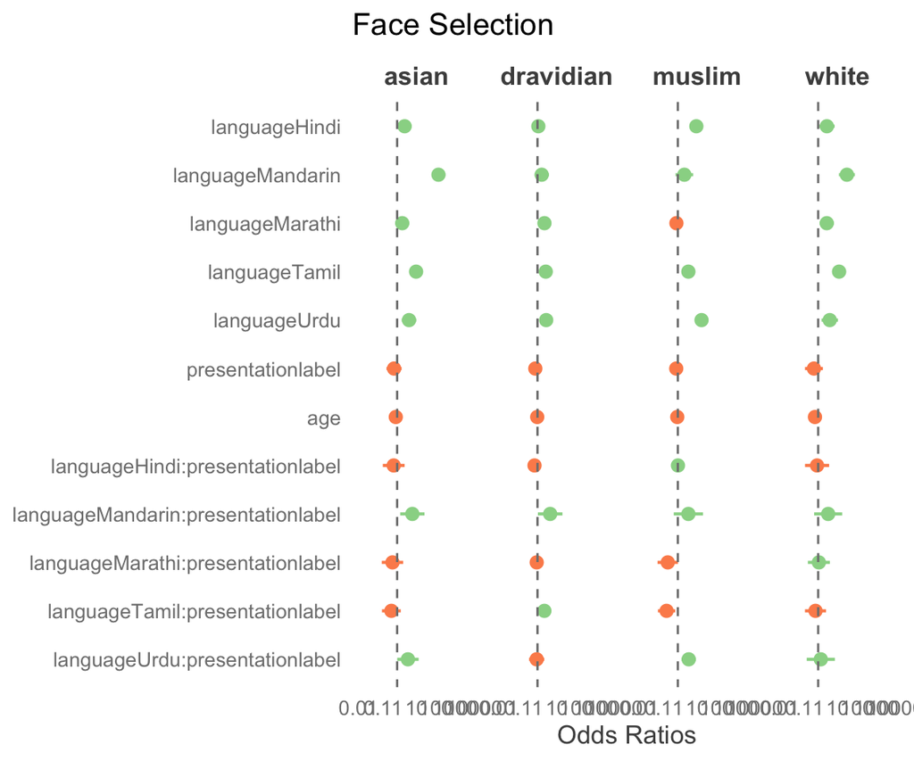

|  | face: asian |  |  | face: dravidian |  |  | face: muslim |  |  | face: white |  |  |
| --- | --- | --- | --- | --- | --- | --- | --- | --- | --- | --- | --- | --- |
| Predictors | Odds Ratios | CI | p | Odds Ratios | CI | p | Odds Ratios | CI | p | Odds Ratios | CI | p |
| (Intercept) | 0.09 | 0.05 – 0.17 | **<0.001** | 0.48 | 0.36 – 0.65 | **<0.001** | 0.20 | 0.13 – 0.31 | **<0.001** | 0.06 | 0.03 – 0.12 | **<0.001** |
| languageHindi | 2.44 | 1.07 – 5.60 | **0.035** | 1.11 | 0.66 – 1.86 | 0.697 | 9.07 | 5.37 – 15.30 | **<0.001** | 2.82 | 1.12 – 7.10 | **0.028** |
| languageMandarin | 136.74 | 60.95 – 306.80 | **<0.001** | 1.65 | 0.71 – 3.85 | 0.244 | 2.18 | 0.76 – 6.19 | 0.145 | 30.57 | 11.85 – 78.86 | **<0.001** |
| languageMarathi | 1.83 | 0.82 – 4.11 | 0.141 | 2.29 | 1.51 – 3.49 | **<0.001** | 0.85 | 0.42 – 1.69 | 0.635 | 2.78 | 1.18 – 6.57 | **0.020** |
| languageTamil | 9.54 | 4.64 – 19.61 | **<0.001** | 2.68 | 1.66 – 4.32 | **<0.001** | 3.52 | 1.92 – 6.43 | **<0.001** | 12.06 | 5.40 – 26.94 | **<0.001** |
| languageUrdu | 4.11 | 1.75 – 9.67 | **0.001** | 2.82 | 1.67 – 4.75 | **<0.001** | 16.84 | 9.63 – 29.46 | **<0.001** | 3.97 | 1.49 – 10.58 | **0.006** |
| presentationlabel | 0.69 | 0.28 – 1.71 | 0.427 | 0.77 | 0.50 – 1.20 | 0.251 | 0.83 | 0.45 – 1.52 | 0.543 | 0.61 | 0.21 – 1.76 | 0.356 |
| age | 0.85 | 0.77 – 0.93 | **0.001** | 0.97 | 0.91 – 1.04 | 0.352 | 0.94 | 0.87 – 1.01 | 0.082 | 0.68 | 0.61 – 0.76 | **<0.001** |
| languageHindi:presentationlabel | 0.66 | 0.18 – 2.43 | 0.537 | 0.70 | 0.32 – 1.52 | 0.373 | 1.02 | 0.48 – 2.14 | 0.964 | 0.88 | 0.21 – 3.69 | 0.860 |
| languageMandarin:presentationlabel | 6.12 | 1.44 – 25.94 | **0.014** | 4.53 | 1.05 – 19.49 | **0.042** | 3.52 | 0.62 – 19.99 | 0.156 | 3.29 | 0.62 – 17.49 | 0.162 |
| languageMarathi:presentationlabel | 0.58 | 0.16 – 2.06 | 0.396 | 0.91 | 0.50 – 1.66 | 0.766 | 0.30 | 0.09 – 1.02 | 0.054 | 1.09 | 0.29 – 4.02 | 0.900 |
| languageTamil:presentationlabel | 0.50 | 0.16 – 1.54 | 0.230 | 2.28 | 1.18 – 4.37 | **0.014** | 0.26 | 0.09 – 0.73 | **0.010** | 0.73 | 0.21 – 2.55 | 0.620 |
| languageUrdu:presentationlabel | 3.61 | 1.01 – 12.91 | **0.049** | 0.91 | 0.37 – 2.23 | 0.830 | 3.66 | 1.55 – 8.67 | **0.003** | 1.37 | 0.26 – 7.33 | 0.712 |
| Observations | 2809 |  |  |  |  |  |  |  |  |  |  |  |
| Nagelkerke’s R<sup>2</sup> | 0.655 |  |  |  |  |  |  |  |  |  |  |  |

```
##
## Iteration 1 - deviance = 6137 - criterion = 0.22
## Iteration 2 - deviance = 6033 - criterion = 0.017
## Iteration 3 - deviance = 6024 - criterion = 0.0015
## Iteration 4 - deviance = 6023 - criterion = 0.00017
## Iteration 5 - deviance = 6023 - criterion = 0.000019
## Iteration 6 - deviance = 6023 - criterion = 0.00000061
## Iteration 7 - deviance = 6023 - criterion = 0.00000000085
```

```
##
## Call:
## mblogit(formula = face ~ language * presentation * age, data = finoeng_df)
##
## Equation for asian vs hindu:
##                                        Estimate Std. Error z value
## (Intercept)                             -2.3940     0.3207   -7.47
## languageHindi                            0.6991     0.4722    1.48
## languageMandarin                         5.4582     0.5408   10.09
## languageMarathi                          0.4895     0.4523    1.08
## languageTamil                            2.2569     0.3868    5.84
## languageUrdu                             1.4645     0.4665    3.14
## presentationlabel                       -0.5968     0.5381   -1.11
## age                                     -0.4257     0.1988   -2.14
## languageHindi:presentationlabel         -0.0234     0.7514   -0.03
## languageMandarin:presentationlabel       1.7458     0.9455    1.85
## languageMarathi:presentationlabel       -0.1416     0.7250   -0.20
## languageTamil:presentationlabel         -0.6706     0.6610   -1.01
## languageUrdu:presentationlabel           1.4290     0.7635    1.87
## languageHindi:age                        0.0485     0.2815    0.17
## languageMandarin:age                     1.2777     0.3034    4.21
## languageMarathi:age                     -0.0977     0.2770   -0.35
## languageTamil:age                        0.0679     0.2411    0.28
## languageUrdu:age                         0.4888     0.2814    1.74
## presentationlabel:age                   -0.0866     0.3112   -0.28
## languageHindi:presentationlabel:age      0.2056     0.4384    0.47
## languageMandarin:presentationlabel:age  -0.2296     0.5221   -0.44
## languageMarathi:presentationlabel:age    0.4491     0.4321    1.04
## languageTamil:presentationlabel:age      0.1012     0.3850    0.26
## languageUrdu:presentationlabel:age      -0.0138     0.4379   -0.03
##                                                    Pr(>|z|)
## (Intercept)                               0.000000000000083 ***
## languageHindi                                        0.1388
## languageMandarin                       < 0.0000000000000002 ***
## languageMarathi                                      0.2792
## languageTamil                             0.000000005365558 ***
## languageUrdu                                         0.0017 **
## presentationlabel                                    0.2674
## age                                                  0.0323 *
## languageHindi:presentationlabel                      0.9752
```

[output cut: 137 more lines]

```
## languageMarathi:age                           0.33859
## languageTamil:age                             0.46173
## languageUrdu:age                              0.00942 **
## presentationlabel:age                         0.60630
## languageHindi:presentationlabel:age           0.79599
## languageMandarin:presentationlabel:age        0.68128
## languageMarathi:presentationlabel:age         0.21081
## languageTamil:presentationlabel:age           0.43291
## languageUrdu:presentationlabel:age            0.23712
## ---
## Signif. codes:  0 '***' 0.001 '**' 0.01 '*' 0.05 '.' 0.1 ' ' 1
##
## Approximate residual Deviance: 6020
## Number of Fisher scoring iterations:  7
## Number of observations:  2809
```

|  | Resid. Df | Resid. Dev | Df | Deviance |
| --- | --- | --- | --- | --- |
| 1 | 11184 | 6259 | NA | NA |
| 2 | 11140 | 6023 | 44 | 236 |

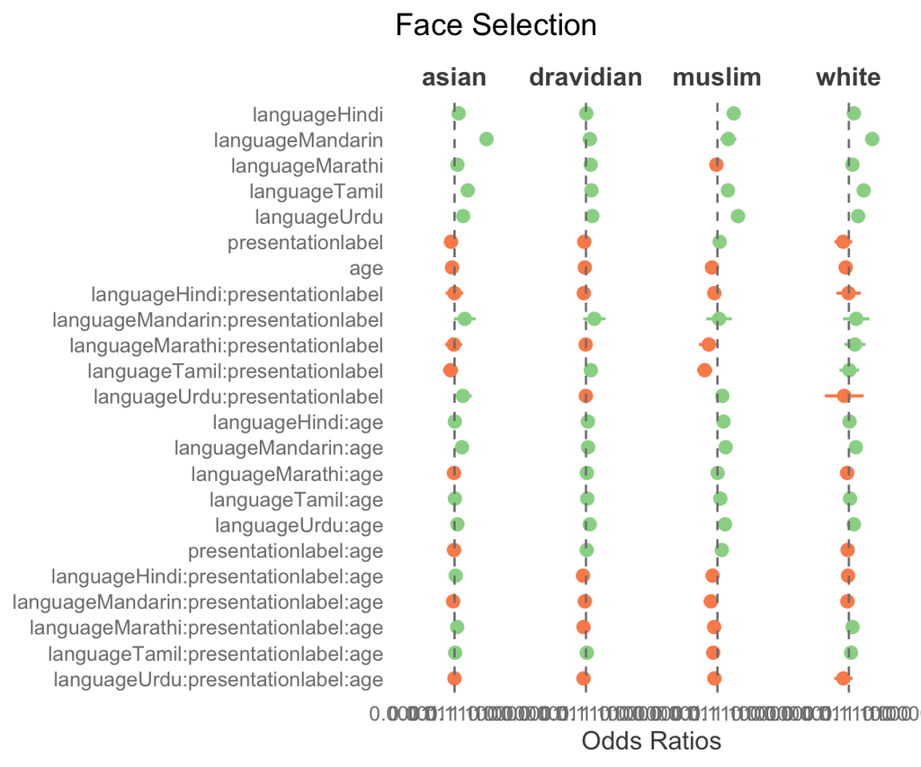

|  | face: asian |  |  | face: dravidian |  |  | face: muslim |  |  | face: white |  |  |
| --- | --- | --- | --- | --- | --- | --- | --- | --- | --- | --- | --- | --- |
| Predictors | Odds Ratios | CI | p | Odds Ratios | CI | p | Odds Ratios | CI | p | Odds Ratios | CI | p |
| (Intercept) | 0.09 | 0.05 – 0.17 | **<0.001** | 0.50 | 0.37 – 0.68 | **<0.001** | 0.11 | 0.06 – 0.22 | **<0.001** | 0.06 | 0.03 – 0.14 | **<0.001** |
| languageHindi | 2.01 | 0.80 – 5.08 | 0.139 | 1.05 | 0.62 – 1.77 | 0.856 | 16.07 | 7.79 – 33.18 | **<0.001** | 2.34 | 0.79 – 6.93 | 0.123 |
| languageMandarin | 234.67 | 81.31 – 677.31 | **<0.001** | 1.92 | 0.57 – 6.45 | 0.288 | 6.38 | 1.62 – 25.13 | **0.008** | 53.33 | 16.00 – 177.78 | **<0.001** |
| languageMarathi | 1.63 | 0.67 – 3.96 | 0.279 | 2.23 | 1.45 – 3.41 | **<0.001** | 0.83 | 0.28 – 2.43 | 0.735 | 1.82 | 0.61 – 5.40 | 0.282 |
| languageTamil | 9.55 | 4.48 – 20.39 | **<0.001** | 2.52 | 1.54 – 4.14 | **<0.001** | 5.99 | 2.69 – 13.34 | **<0.001** | 12.63 | 5.21 – 30.60 | **<0.001** |
| languageUrdu | 4.33 | 1.73 – 10.79 | **0.002** | 2.94 | 1.69 – 5.09 | **<0.001** | 33.29 | 15.46 – 71.68 | **<0.001** | 4.80 | 1.68 – 13.75 | **0.003** |
| presentationlabel | 0.55 | 0.19 – 1.58 | 0.267 | 0.74 | 0.47 – 1.16 | 0.188 | 1.45 | 0.66 – 3.22 | 0.357 | 0.38 | 0.08 – 1.73 | 0.212 |
| age | 0.65 | 0.44 – 0.96 | **0.032** | 0.81 | 0.67 – 0.99 | **0.039** | 0.39 | 0.27 – 0.56 | **<0.001** | 0.58 | 0.37 – 0.92 | **0.020** |
| languageHindi:presentationlabel | 0.98 | 0.22 – 4.26 | 0.975 | 0.69 | 0.31 – 1.52 | 0.358 | 0.58 | 0.24 – 1.44 | 0.242 | 0.94 | 0.12 – 7.55 | 0.957 |
| languageMandarin:presentationlabel | 5.73 | 0.90 – 36.56 | 0.065 | 4.17 | 0.62 – 28.08 | 0.142 | 1.32 | 0.15 – 11.59 | 0.804 | 3.47 | 0.37 – 32.80 | 0.277 |
| languageMarathi:presentationlabel | 0.87 | 0.21 – 3.59 | 0.845 | 0.94 | 0.51 – 1.73 | 0.848 | 0.23 | 0.04 – 1.22 | 0.083 | 2.80 | 0.47 – 16.90 | 0.260 |
| languageTamil:presentationlabel | 0.51 | 0.14 – 1.87 | 0.310 | 2.28 | 1.17 – 4.46 | **0.016** | 0.11 | 0.03 – 0.41 | **0.001** | 1.08 | 0.20 – 5.69 | 0.931 |
| languageUrdu:presentationlabel | 4.17 | 0.93 – 18.64 | 0.061 | 0.97 | 0.35 – 2.65 | 0.950 | 2.31 | 0.79 – 6.70 | 0.125 | 0.45 | 0.02 – 12.35 | 0.635 |
| languageHindi:age | 1.05 | 0.60 – 1.82 | 0.863 | 1.39 | 0.99 – 1.93 | 0.055 | 2.82 | 1.88 – 4.24 | **<0.001** | 1.11 | 0.59 – 2.09 | 0.736 |
| languageMandarin:age | 3.59 | 1.98 – 6.50 | **<0.001** | 1.43 | 0.75 – 2.70 | 0.276 | 4.06 | 1.89 – 8.72 | **<0.001** | 3.28 | 1.67 – 6.45 | **0.001** |
| languageMarathi:age | 0.91 | 0.53 – 1.56 | 0.724 | 1.17 | 0.89 – 1.54 | 0.261 | 1.04 | 0.58 – 1.85 | 0.901 | 0.74 | 0.40 – 1.38 | 0.339 |
| languageTamil:age | 1.07 | 0.67 – 1.72 | 0.778 | 1.25 | 0.91 – 1.72 | 0.160 | 1.62 | 1.03 – 2.57 | **0.039** | 1.22 | 0.72 – 2.09 | 0.462 |
| languageUrdu:age | 1.63 | 0.94 – 2.83 | 0.082 | 1.88 | 1.34 – 2.64 | **<0.001** | 3.64 | 2.37 – 5.59 | **<0.001** | 2.32 | 1.23 – 4.38 | **0.009** |
| presentationlabel:age | 0.92 | 0.50 – 1.69 | 0.781 | 1.14 | 0.86 – 1.51 | 0.377 | 2.10 | 1.34 – 3.31 | **0.001** | 0.81 | 0.36 – 1.81 | 0.606 |
| languageHindi:presentationlabel:age | 1.23 | 0.52 – 2.90 | 0.639 | 0.60 | 0.36 – 0.98 | **0.041** | 0.43 | 0.26 – 0.73 | **0.002** | 0.87 | 0.29 – 2.58 | 0.796 |
| languageMandarin:presentationlabel:age | 0.79 | 0.29 – 2.21 | 0.660 | 0.82 | 0.29 – 2.31 | 0.711 | 0.33 | 0.10 – 1.10 | 0.070 | 0.78 | 0.23 – 2.60 | 0.681 |
| languageMarathi:presentationlabel:age | 1.57 | 0.67 – 3.65 | 0.299 | 0.66 | 0.45 – 0.97 | **0.032** | 0.57 | 0.23 – 1.41 | 0.224 | 1.86 | 0.70 – 4.91 | 0.211 |
| languageTamil:presentationlabel:age | 1.11 | 0.52 – 2.35 | 0.793 | 1.16 | 0.76 – 1.77 | 0.495 | 0.49 | 0.23 – 1.01 | 0.052 | 1.44 | 0.58 – 3.56 | 0.433 |
| languageUrdu:presentationlabel:age | 0.99 | 0.42 – 2.33 | 0.975 | 0.66 | 0.36 – 1.19 | 0.166 | 0.60 | 0.32 – 1.10 | 0.098 | 0.39 | 0.08 – 1.86 | 0.237 |
| Observations | 2809 |  |  |  |  |  |  |  |  |  |  |  |
| Nagelkerke’s R<sup>2</sup> | 0.686 |  |  |  |  |  |  |  |  |  |  |  |